# Unit 4 and 5

Author

Manish Patel

# 1 UNIT-4 IMMUTABLE DATA STRUCTURES

### 1.0.1 4.1 Strings:

Strings in Python are immutable, meaning their values cannot be changed after creation.

- **Immutability:**
  - Strings cannot be modified once created.

```python
my_string = "Hello, World!"
my_string[0] = "hi"
```

```
TypeError: 'str' object does not support item assignment
```

- **Declaring:**
  - Syntax: `my_string = "Hello, World!"`
  - Description: Declares a string with the value “Hello, World!”.

```python
my_string = "Hello, World!"
```

- **Accessing through for loop:**
  - Syntax:

    ```python
    for char in my_string:
        print(char)
    ```

  - Description: Accesses each character in the string using a for loop.

```python
for char in my_string:
        print(char, end = "")
```

```
Hello, World!
```

- **Slicing:**
  - Syntax: `substring = my_string[7:12]`
  - Description: Creates a substring from index 7 to 11.

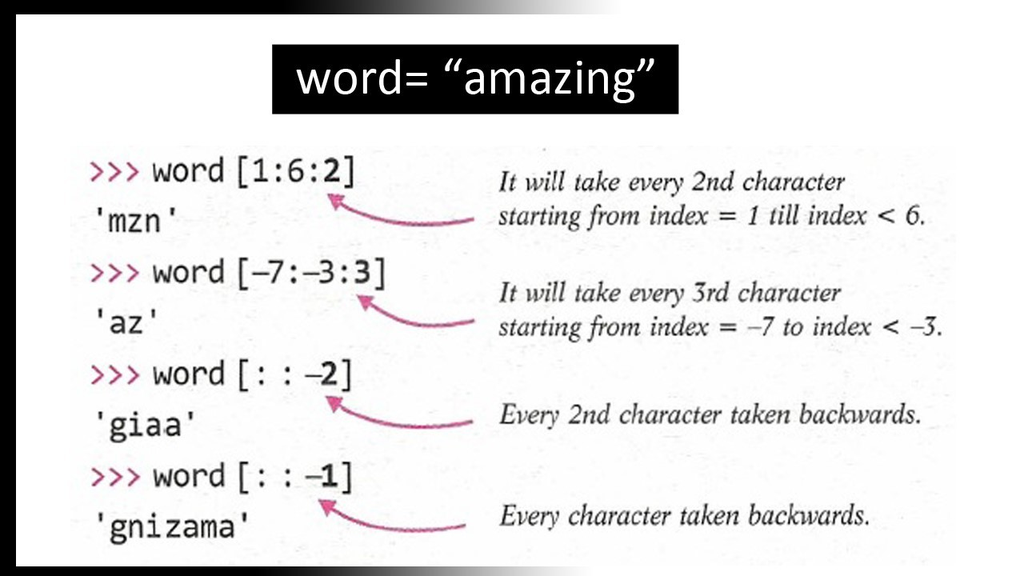

image.png

```python
substring = my_string[7:12]
substring
```

```
'World'
```

- **Concatenation:**
  - Syntax: `new_string = my_string + " How are you?"`
  - Description: Concatenates a new string ” How are you?“.

```python
new_string = my_string + " How are you?"
new_string
```

```
'Hello, World! How are you?'
```

- **Length (len):**
  - Syntax: `length = len(my_string)`
  - Description: Gets the length of the string.

```python
length = len(my_string)
length
```

```
13
```

- **capitalize():**
  - Syntax: `capitalized = my_string.capitalize()`
  - Description: Returns a capitalized version of the string.

```python
capitalized = my_string.capitalize()
capitalized
```

```
'Hello, world!'
```

- **enumerate():**
  - Syntax:

    ```python
    for index, char in enumerate(my_string):
        print(index, char)
    ```

  - Description: Enumerates through the string, printing index and character.

```python
for index, char in enumerate(my_string):
    print(index, char)
```

```
0 H
1 e
2 l
3 l
4 o
5 ,
6
7 W
8 o
9 r
10 l
11 d
12 !
```

- **isalnum():**
  - Syntax: `is_alphanumeric = my_string.isalnum()`
  - Description: Checks if the string is alphanumeric.

```python
is_alphanumeric = my_string.isalnum()
is_alphanumeric
```

```
False
```

- **isalpha():**
  - Syntax: `is_alpha = my_string.isalpha()`
  - Description: Checks if the string is alphabetic.

```python
is_alpha = my_string.isalpha()
is_alpha
```

```
False
```

- **islower():**
  - Syntax: `is_lower = my_string.islower()`
  - Description: Checks if the string is in lowercase.

```python
is_lower = my_string.islower()
is_lower
```

```
False
```

- **isupper():**
  - Syntax: `is_upper = my_string.isupper()`
  - Description: Checks if the string is in uppercase.

```python
is_upper = my_string.isupper()
is_upper
```

```
False
```

- **lower():**
  - Syntax: `lower_case = my_string.lower()`
  - Description: Converts the string to lowercase.

```python
lower_case = my_string.lower()
lower_case
```

```
'hello, world!'
```

- **upper():**
  - Syntax: `upper_case = my_string.upper()`
  - Description: Converts the string to uppercase.

```python
upper_case = my_string.upper()
upper_case
```

```
'HELLO, WORLD!'
```

- **isnumeric():**
  - Syntax: `is_numeric = my_string.isnumeric()`
  - Description: Checks if the string is numeric.

```python
is_numeric = my_string.isnumeric()
is_numeric
```

```
False
```

- **find():**
  - Syntax: `index = my_string.find("World")`
  - Description: Finds the index of the substring “World”.
  - If the substring is not found, find() returns -1.

```python
index = my_string.find("World")
index
```

```
7
```

- **index():**
  - Syntax: `index = my_string.index("World")`
  - Description: Finds the index of the substring “World”.
  - If the substring is not found, index() raises a ValueError.

```python
index = my_string.index("World")
index
```

```
7
```

- **split():**
  - Syntax: `words = my_string.split(",")`
  - Description: Splits the string into a list of words using a comma as a delimiter.

```python
words = my_string.split(",")
words
```

```
['Hello', ' World!']
```

- **strip():**
  - Syntax: `stripped = my_string.strip()`
  - Description: Removes leading and trailing whitespaces from the string.

```python
stripped = my_string.strip()
stripped
```

```
'Hello, World!'
```

- **Removing punctuation using translate():**
  - Syntax:

    ```python
    import string
    translator = str.maketrans("", "", string.punctuation)
    no_punctuation = my_string.translate(translator)
    ```

  - Description: Removes punctuation from the string.

```python
import string
translator = str.maketrans("", "", string.punctuation)
no_punctuation = my_string.translate(translator)
no_punctuation
```

```
'Hello World'
```

- **count():**
  - Syntax: `occurrence = my_string.count("l")`
  - Description: Counts the occurrences of the character “l” in the string.

```python
occurrence = my_string.count("l")
occurrence
```

```
3
```

## 1.1 4.2 Tuples:

Tuples are immutable sequences.

- **Immutability:**
  - Tuples cannot be modified once created.

```python
my_tuple = (1, 2, 3)
my_tuple[1] = 9
```

```
TypeError: 'tuple' object does not support item assignment
```

- **Create:**
  - Syntax: `my_tuple = (1, 2, 3)`
  - Description: Creates a tuple with values 1, 2, and 3.

```python
my_tuple = (1,2,3)
```

- **Assign:**
  - Syntax: `a, b, c = my_tuple`
  - Description: Assigns values from the tuple to variables.

```python
a, b, c = my_tuple
print(a,b,c)
```

```
1 2 3
```

- **Access:**
  - Syntax: `value = my_tuple[1]`
  - Description: Accesses the value at index 1 of the tuple.

```python
value = my_tuple[1]
value
```

```
2
```

- **Delete (del):**
  - Syntax: `del my_tuple`
  - Description: Deletes the tuple.

```python
del my_tuple
```

- **Slicing:**
  - Syntax: `subset = my_tuple[1:3]`
  - Description: Creates a subset of the tuple from index 1 to 2.

```python
my_tuple = (1,2,3)
subset = my_tuple[1:3]
subset
```

```
(2, 3)
```

- **Concatenation:**
  - Syntax: `new_tuple = my_tuple + (4, 5)`
  - Description: Concatenates a new tuple.

```python
new_tuple = my_tuple + (4, 5)
new_tuple
```

```
(1, 2, 3, 4, 5)
```

- **Comparing tuples:**
  - Syntax: `compare_result = (1, 2, 3) == (1, 2, 3)`
  - Description: Compares two tuples for equality.

```python
compare_result = (1, 2, 3) == (1, 2, 3)
compare_result
```

```
True
```

- **Count function:**
  - Syntax: `occurrences = my_tuple.count(2)`
  - Description: Counts the occurrences of the value 2 in the tuple.

```python
occurrences = my_tuple.count(2)
occurrences
```

```
1
```

## 1.2 4.3 Built-in Functions:

Python provides various built-in functions for common operations.

- **sorted():**
  - Syntax: `sorted_list = sorted([3, 1, 4, 1, 5, 9, 2])`
  - Description: Returns a sorted version of the list.

```python
sorted_list = sorted([3, 1, 4, 1, 5, 9, 2])
print(sorted_list)
print(type(sorted_list))
```

```
[1, 1, 2, 3, 4, 5, 9]
<class 'list'>
```

- **reversed():**
  - Syntax: `reversed_list = list(reversed([3, 1, 4, 1, 5, 9, 2]))`
  - Description: Returns a reversed version of the list.

```python
reversed_list = list(reversed([3, 1, 4, 1, 5, 9, 2]))
reversed_list
```

```
[2, 9, 5, 1, 4, 1, 3]
```

- **min():**
  - Syntax: `minimum_value = min(3, 1, 4, 1, 5, 9, 2)`
  - Description: Returns the minimum value from the arguments.

```python
minimum_value = min(3, 1, 4, 1, 5, 9, 2)
minimum_value
```

```
1
```

- **max():**
  - Syntax: `maximum_value = max(3, 1, 4, 1, 5, 9, 2)`
  - Description: Returns the maximum value from the arguments.

```python
maximum_value = max(3, 1, 4, 1, 5, 9, 2)
maximum_value
```

```
9
```

```python
a={1,2,3}
b={1,2,3,4,5}
a>b
```

```
False
```

# 2 UNIT-5 MUTABLE DATA STRUCTURES

## 2.1 5.1 Lists:

Lists in Python are mutable, meaning their elements can be modified after creation.

- **Mutability:**
  - Lists can be modified after creation.

```python
my_list = [1, 2, 3]
my_list[0] = 100
my_list
```

```
[100, 2, 3]
```

- **Declaring:**
  - Syntax: `my_list = [1, 2, 3]`
  - Description: Declares a list with values 1, 2, and 3.

```python
my_list = [1, 2, 3]
my_list
```

```
[1, 2, 3]
```

- **Accessing through for loop:**
  - Syntax:

    ```python
    for item in my_list:
        print(item)
    ```

  - Description: Accesses each element in the list using a for loop.

```python
for item in my_list:
    print(item)
```

```
1
2
3
```

- **append():**
  - Syntax: `my_list.append(4)`
  - Description: Appends the value 4 to the end of the list.

```python
my_list.append(4)
my_list
```

```
[1, 2, 3, 4]
```

- **count():**
  - Syntax: `count = my_list.count(2)`
  - Description: Counts the occurrences of the value 2 in the list.

```python
count = my_list.count(4)
count
```

```
1
```

- **extend():**
  - Syntax: `my_list.extend([5, 6])`
  - Description: Extends the list by adding elements from another list.

```python
my_list.extend([5, 6])
my_list
```

```
[1, 2, 3, 4, 5, 6]
```

- **index():**
  - Syntax: `index = my_list.index(3)`
  - Description: Returns the index of the first occurrence of the value 3.

```python
index = my_list.index(3)
index
```

```
2
```

- **insert():**
  - Syntax: `my_list.insert(1, 7)`
  - Description: Inserts the value 7 at index 1 in the list.

```python
my_list.insert(1, 7)
my_list
```

```
[1, 7, 2, 3, 4, 5, 6]
```

- **pop():**
  - Syntax: `popped_value = my_list.pop()`
  - Description: Removes and returns the last element from the list.

```python
popped_value = my_list.pop()
popped_value
```

```
6
```

- **remove():**
  - Syntax: `my_list.remove(2)`
  - Description: Removes the first occurrence of the value 2 from the list.

```python
my_list.remove(2)
my_list
```

```
[1, 7, 3, 4, 5]
```

- **reverse():**
  - Syntax: `my_list.reverse()`
  - Description: Reverses the order of elements in the list.

```python
my_list.reverse()

my_list
```

```
[5, 4, 3, 7, 1]
```

- **sort():**
  - Syntax: `my_list.sort()`
  - Description: Sorts the elements of the list in ascending order.

```python
my_list.sort()
my_list
```

```
[1, 3, 4, 5, 7]
```

## 2.2 5.2 Dictionaries:

Dictionaries in Python are mutable collections of key-value pairs.

- **Create:**
  - Syntax: `my_dict = {"name": "John", "age": 25}`
  - Description: Creates a dictionary with key-value pairs.

```python
my_dict = {"name": "John", "age": 25}
my_dict
```

```
{'name': 'John', 'age': 25}
```

- **Access using for loop:**
  - Syntax:

    ```python
    for key, value in my_dict.items():
        print(key, value)
    ```

  - Description: Accesses key-value pairs using a for loop.

```python
for key, value in my_dict.items():
    print(key, value)
```

```
name John
age 25
```

- **clear():**
  - Syntax: `my_dict.clear()`
  - Description: Removes all items from the dictionary.

```python
my_dict.clear()
my_dict
```

```
{}
```

- **copy():**
  - Syntax: `new_dict = my_dict.copy()`
  - Description: Creates a shallow copy of the dictionary.

```python
my_dict = {"name": "John", "age": 25}
new_dict = my_dict.copy()
new_dict
```

```
{'name': 'John', 'age': 25}
```

```python
my_dict = {'name': 'John', 'age': 25, 'languages': ['Python', 'Java']}

shallow_copy = my_dict.copy()

my_dict['name'] = 'Java'
my_dict['languages'][0] = 'C++'

print(my_dict)
print(shallow_copy)
```

```
{'name': 'Java', 'age': 25, 'languages': ['C++', 'Java']}
{'name': 'John', 'age': 25, 'languages': ['C++', 'Java']}
```

```python
from copy import deepcopy

new_dict = deepcopy(my_dict)
new_dict

my_dict['name'] = 'java'
print(my_dict)
print(new_dict)
```

```
{'name': 'java', 'age': 25, 'languages': ['C++', 'Java']}
{'name': 'Java', 'age': 25, 'languages': ['C++', 'Java']}
```

- **fromkeys():**
  - Syntax: `new_dict = dict.fromkeys(["name", "age"], "Unknown")`
  - Description: Creates a new dictionary with specified keys and a default value.

```python
new_dict = dict.fromkeys(["name", "age"], "Unknown")
new_dict
```

```
{'name': 'Unknown', 'age': 'Unknown'}
```

- **get():**
  - Syntax: `value = my_dict.get("name", "Not found")`
  - Description: Gets the value for the specified key, or a default value if the key is not present.

```python
value = my_dict.get("name", "Not found")
value
```

```
'java'
```

- **items():**
  - Syntax: `items = my_dict.items()`
  - Description: Returns a view of key-value pairs in the dictionary.

```python
items = my_dict.items()
items
```

```
dict_items([('name', 'java'), ('age', 25), ('languages', ['C++', 'Java'])])
```

- **keys():**
  - Syntax: `keys = my_dict.keys()`
  - Description: Returns a view of keys in the dictionary.

```python
keys = my_dict.keys()
keys
```

```
dict_keys(['name', 'age', 'languages'])
```

- **update():**
  - Syntax: `my_dict.update({"age": 26, "city": "New York"})`
  - Description: Updates the dictionary with key-value pairs from another dictionary.

```python
my_dict.update({"age": 26, "city": "New York"})
my_dict
```

```
{'name': 'java', 'age': 26, 'languages': ['C++', 'Java'], 'city': 'New York'}
```

- **values():**
  - Syntax: `values = my_dict.values()`
  - Description: Returns a view of values in the dictionary.

```python
values = my_dict.values()
values
```

```
dict_values(['java', 26, ['C++', 'Java'], 'New York'])
```

## 2.3 5.3 Sets:

Sets in Python are mutable, unordered collections of unique elements.

- **Declaring:**
  - Syntax: `my_set = {1, 2, 3}`
  - Description: Declares a set with values 1, 2, and 3.

```python
my_set = {1, 2, 3}
```

- **Accessing:**
  - Sets do not support indexing or slicing.

```python
my_set[0]
```

```
TypeError: 'set' object is not subscriptable
```

- **set():**
  - Syntax: `new_set = set([3, 4, 5])`
  - Description: Creates a set from an iterable.

```python
new_set = set([3, 4, 5])
new_set
```

```
{3, 4, 5}
```

- **frozenset():**
  - Syntax: `frozen_set = frozenset([1, 2, 3])`
  - Description: Creates an immutable frozenset from an iterable.

```python
frozen_set = frozenset([1, 2, 3])
frozen_set
```

```
frozenset({1, 2, 3})
```

- **issubset():**
  - Syntax: `is_subset = set1.issubset(set2)`
  - Description: Checks if set1 is a subset of set2.

```python
set1 = {1,2}
set2 = {1,2,3}
is_subset = set1.issubset(set2)
is_subset
```

```
True
```

- **issuperset():**
  - Syntax: `is_superset = set1.issuperset(set2)`
  - Description: Checks if set1 is a superset of set2.

```python
is_superset = set2.issuperset(set1)
is_superset
```

```
True
```

- **union():**
  - Syntax: `union_set = set1.union(set2)`
  - Description: Returns the union of two sets.

```python
union_set = set1.union(set2)
union_set
```

```
{1, 2, 3}
```

- **intersection():**
  - Syntax: `intersection_set = set1.intersection(set2)`
  - Description: Returns the intersection of two sets.

```python
intersection_set = set1.intersection(set2)
intersection_set
```

```
{1, 2}
```

- **difference():**
  - Syntax: `difference_set = set1.difference(set2)`
  - Description: Returns the difference between two sets.

```python
set1 = {1,2,3}
set2 = {3,4,5}
difference_set = set1.difference(set2)
difference_set
```

```
{1, 2}
```

```python
set1 - set2
```

```
{1, 2}
```

- **symmetric_difference():**
  - Syntax: `symmetric_difference_set = set1.symmetric_difference(set2)`
  - Description: Returns the symmetric difference between two sets.

```python
symmetric_difference_set = set1.symmetric_difference(set2)
symmetric_difference_set
```

```
{1, 2, 4, 5}
```

- **copy():**
  - Syntax: `new_set = my_set.copy()`
  - Description: Creates a shallow copy of the set.

```python
new_set = my_set.copy()
new_set
```

```
{1, 2, 3}
```

## 2.4 5.4 Lambda functions:

Lambda functions are anonymous functions defined using the `lambda` keyword.

- **Map:**
  - Syntax: `mapped_values = map(lambda x: x * 2, [1, 2, 3])`
  - Description: Applies the lambda function to each element of the iterable.

```python
mapped_values = map(lambda x: x * 2, [1, 2, 3])
print(list(mapped_values))
```

```
[2, 4, 6]
```

- **Reduce:**
  - Syntax: `from functools import reduce; result = reduce(lambda x, y: x + y, [1, 2, 3])`
  - Description: Applies the lambda function cumulatively to the elements of the iterable.

```python
from functools import reduce
result = reduce(lambda x, y: x + y, [1, 2, 3])
result
```

```
6
```

- **Filter:**
  - Syntax: `filtered_values = filter(lambda x: x % 2 == 0, [1, 2, 3, 4, 5])`
  - Description: Filters elements of the iterable based on the lambda function.

```python
filtered_values = filter(lambda x: x % 2 == 0, [1, 2, 3, 4, 5])
print(list(filtered_values))
```

```
[2, 4]
```